# Data Exploration and Analysis Project using Python

### Does Club Spending in Professional Football Have Direct Bearing on Success? Does Location?

### Executive Summary

The English Premier League, as is referred to the current structure of the English First Division football (soccer), is the world's most popular footballing league. Having redesigned its model from the traditional league in 1992, the "Premier League" grew to become the biggest global brand in league football in subsequent years, overtaking the leagues in Italy and Spain in terms of popularity and global fanbase. As such, it is no surprise that the league boasts of an incredible concentration of investment and expenditure from financial consortiums and groups from all across the world. The past couple of decades in particular have seen a mouthwatering amount of investment flood into the league, of which the sources range from Emrati royals to Russian oligarchs. With most of the top clubs all comfortably having spent over a billion euros just in accumulated player transfer fees (the sum paid to the club a player is being acquired from), the scrutiny over the concentration of wealth in the league is ever-increasing.

Using the correlation analyses shown below, we can gather a fair insight into the drive that expenditure has provided clubs in gaining "success", measured by the total number of points a club has accumulated since the 1992/93 season. As expected, in exploring the correlation between individual club expenditure and point accumulation, we can conclude with an observed correlation coefficient of 0.924 that there is a strong positive correlation between club expenditure and club success. The other area of examination focused on the spread of points across cities in the UK, whereby we do also notice that there is a positive relationship between club location and perceived success. However, this examination may have grounds for further research as the correlation is likely spurious due to confounding factors and unexamined societal or financial mechanisms associated with various locations in the United Kingdom.

### Research Questions

The research questions that will be used to explore the dataset and proposed analyses are as follows:

##### Research Topic 1: Is there observable correlation between a Premier League team's total spending and success achieved? Do we have a case for introducing caps on spending and wages like other sports have?

##### Research Topic 2: Is there any relationship between club location and its success in the league? Are certain locations primed for success?

### Data Description and Sources

##### Dataset

The data used for the purpose of the analyses here draws from three separate datasets:

- "premclubdetails.csv" : directory of all 50 Premier League clubs (92/93 - 22/23) and their primary details (location, top goalscorer, etc.)
- "premspending.csv" : data for clubs' expenditures (on transfers), incomes and balances during the timeframe
- 'premtotals.csv" : data for all clubs' performances (matches played, won, points accumulated, etc.) during the timeframe

##### Controls

To have a control for the measure of "success", we will use the total points earned as a direct yardstick for how successful a team has been during this timeframe. Since the data used for this analysis uses monetary values as a key independent variable, we also require a uniform understanding and measure of monetary values across the data.

##### Monetary Values

The final dataset provides a clean combined view of all clubs and the appropriate variables needed for examination of the listed research questions. The monetary values in the original datasets were in either billions or millions of euros; in order to clean the data for a uniform examination, all values were converted to millions of euros.

##### Null Values

In order to further clean the dataset, expenditure and information for Wimbledon AFC were considered null values. This is mostly due to publicly accessible data on Wimbledon's finances (and changes to club structure) being murky and the data source choosing to omit their expenditure information in the interest of analytical veracity.

##### Data Sources

The data used for exploring the research questions in this analysis are derived from two sources:

1. Official Premier League website (premierleague.com)
2. Transfermarkt.com

##### Dataset

The final dataframe consists of the following columns and associated values for each:

- Club: Name of the Premier League club
- Location: Premier League club's location/city within the UK
- Income: Total income reported by the club in the timeframe
- Expenditure: Total amount of money spent by the club on transfers in the timeframe
- Points Position: Position of the club in the final count of all points accumulated in the timeframe
- Played: Total number of matches contested by the club in the timeframe
- Won: Total number of contested matches won by the club in the timeframe
- Points: Total points accumulated in the league by the club in the timeframe

### Data Exploration

```python
import pandas as pd
import plotly.express as px
import plotly.graph_objects as go
import os
```

```python
os.chdir('C:\\Users\\barda\\Downloads\\Python NoteBooks\\MidtermFiles')
```

```python
club_details = pd.read_csv('premclubdetails.csv')
spending = pd.read_csv('premspending.csv')
totals = pd.read_csv('premtotals.csv')
```

```python
club_spending = pd.merge(club_details[['Club', 'Location']], spending[['Club', 'Expenditure', 'Income']], on ='Club', how='left')
club_spending.fillna('NaN', inplace=True)
```

```python
final_df = pd.merge(club_spending, totals[['Position', 'Club', 'Played', 'Won', 'Points']], on='Club', how='left')
final_df.fillna('NaN', inplace=True)
```

```python
#D1 Renaming the "Position" Column for better understanding

final_df.rename(columns={'Position': 'PointsPosition'}, inplace=True)
```

```python
#D2 Resetting the index so that values can be only referred to by Club name

final_df.set_index('Club', inplace=True)
```

```python
#D3 Removing "m" values from columns for numerical consistency

final_df['Income'] = final_df['Income'].str.replace('m', '')
final_df['Expenditure'] = final_df['Expenditure'].str.replace('m', '')
```

```python
#D4 Converting Expenditure and Income columns back to floats for numerical analyses

final_df['Expenditure'] = final_df["Expenditure"].astype(float)
final_df['Income'] = final_df["Income"].astype(float)
```

```python
#D5 Removing null values for numerical analyses

numeric_df = final_df.dropna(subset=['Expenditure', 'Income'])
```

```python
#D6 Exporting csv for input in other notebook

numeric_df.to_csv('finalversionfile.csv', index=True)
```

##### Categorical Variable

After introducing and organizing the dataset as well as dropping any unnecessary or null values, we can examine the data and general tendencies our variables exhibit before delving into the analysis.

```
Count for Location:
 London            10
Liverpool          2
Sheffield          2
Birmingham         2
Manchester         2
Bolton             1
Norwich            1
Wigan              1
West Bromwich      1
Watford            1
Swindon            1
Swansea            1
Sunderland         1
Stoke-on-Trent     1
Southampton        1
Barnsley           1
Reading            1
Portsmouth         1
Oldham             1
West Bridgford     1
Newcastle          1
Bournemouth        1
Middlesbrough      1
Blackburn          1
Leicester          1
Leeds              1
Ipswich            1
Huddersfield       1
Blackpool          1
Derby              1
Coventry           1
Cardiff            1
Burnley            1
Brighton           1
Bradford           1
Wolverhampton      1
Name: Location, dtype: int64
```

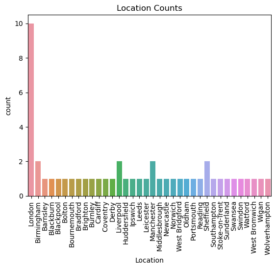

```python
#D7 Categorical Variable Examination: Location

import seaborn as sns
import matplotlib.pyplot as plt

loc_counts = final_df['Location'].value_counts()
print('Count for Location: \n', loc_counts)

sns.countplot(x='Location', data=final_df)
plt.title('Location Counts')
plt.xticks(rotation=90)
plt.show()
```

##### Continuous Variables

```python
#D8 Descriptive statistics for Variables (without columns for the null values)
print(numeric_df[['Expenditure', 'Income', 'PointsPosition', 'Won', 'Points']].describe())
```

```
       Expenditure       Income  PointsPosition         Won       Points
count    48.000000    48.000000       48.000000   48.000000    48.000000
mean    614.500417   360.450417       25.187500  182.166667   671.875000
std     715.373893   319.863192       14.708018  192.889267   667.674676
min       7.630000    12.430000        1.000000    5.000000    30.000000
25%     170.485000   144.257500       12.750000   65.000000   255.250000
50%     354.785000   251.440000       25.000000   99.000000   388.500000
75%     758.785000   446.830000       37.250000  232.750000   856.750000
max    3140.000000  1450.000000       50.000000  721.000000  2426.000000
```

```python
import matplotlib.pyplot as plt
```

[figure not shown]

```python
numeric_df[['Points']].hist(bins=10, figsize=(10,8))
plt.title('Where do most clubs lie in terms of spending?')
plt.xlabel('Total Expenditure')
plt.ylabel('Club Count')
plt.show()
```

##### Multi-Variable Summaries

1) loc_exp_inc

In our first multi-variable examination, we produced descriptive statistics for a varible that provides a cumulative "balance" (by subtracting expenditure from club income) through all 36 club locations in the dataset (Code D9 Location and Expenditure Balance Compared). We can gather from the standard deviation of 300 for a dataset mean of -160 that the data has rather large variability. Since the dataset also appears to be skewed towards lower values (which makes sense since there are more "smaller", less wealthy clubs and wealth is concentrated amongst "big clubs in the league), we would need to recommend further examination by adjusting for club sizes before making any conclusions.

```python
# Multiple Variable Summaries

#D9 Location and Expenditure Balance compared

loc_exp_inc = numeric_df.groupby("Location")[["Expenditure", "Income"]].mean()
loc_exp_inc = loc_exp_inc["Income"] - loc_exp_inc["Expenditure"]
```

```python
loc_exp_inc_summary = loc_exp_inc.describe()
loc_exp_inc_summary
```

```
count      36.000000
mean     -160.402515
std       300.876891
min     -1575.820000
25%      -203.170000
50%       -55.135000
75%         6.197500
max        91.820000
dtype: float64
```

2) club_exp_points

```python
#D10 Expenditure binned

club_exp_points = numeric_df.groupby("Club")[["Expenditure", "Points"]].mean()
```

```python
exp_bins = pd.cut(club_exp_points["Expenditure"], bins=[0, 200, 400, 600, 800, 1000, 1200, 1400, 1600, 1800], labels=["0-200", "200-400", "400-600", "600-800", "800-1000", "1000-1200", "1200-1400", "1400-1600", "1600-1800"])
```

```python
exp_points_summary = club_exp_points.groupby(exp_bins)["Points"].mean()
print(exp_points_summary)
```

```
Expenditure
0-200         189.200000
200-400       367.083333
400-600       485.500000
600-800       676.250000
800-1000     1087.000000
1000-1200    1435.333333
1200-1400    1472.000000
1400-1600            NaN
1600-1800    2028.500000
Name: Points, dtype: float64
```

### Analysis and Findings

1. Expenditure Correlation:

```python
final_df1 = final_df.sort_values('Expenditure', ascending=True)
```

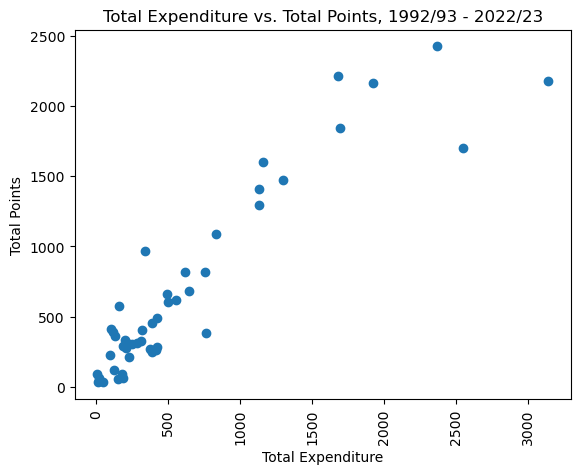

```python
#AN1 Total Expenditure vs Total Point SCTs

import matplotlib.pyplot as plt

plt.scatter(final_df1['Expenditure'], final_df1['Points'])
plt.xlabel('Total Expenditure')
plt.xticks(rotation=90)
plt.ylabel('Total Points')
plt.title('Total Expenditure vs. Total Points, 1992/93 - 2022/23')
plt.show()
```

```python
#AN2 Correlation Code: Expenditure

corr_exp_points = numeric_df["Expenditure"].corr(numeric_df["Points"])
print("Correlation between Expenditure and Total Points:", corr_exp_points)
```

```
Correlation between Expenditure and Total Points: 0.92489769087563
```

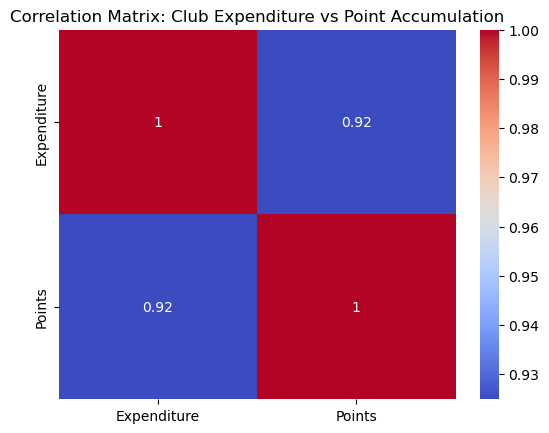

```python
#AN3 Correlation Analysis between points and expenditure

corr_matrix_exp = numeric_df[["Expenditure", "Points"]].corr()

sns.heatmap(corr_matrix_exp, annot=True, cmap="coolwarm")
plt.title("Correlation Matrix: Club Expenditure vs Point Accumulation")
plt.show()
```

1. Location Relationship:

A standard deviation of 497 points when means of all locations' accumulated points are described as a variable suggest that some locations are indeed primed to do better than others in the UK. London might not be the best yardstick to compare this with as it is the capital city with a 20% concentration of all clubs in the dataset and there likely are other underlying mechanisms (on top of spending) contributing to London club successes. However, other hotbeds of football (and decently sized cities) such as Liverpool and Manchester provide a more telling picture.

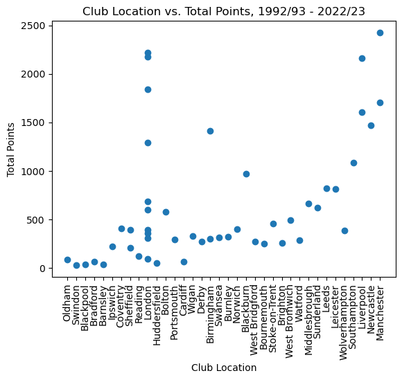

```python
#AN4 Scatter Plot - Location

plt.scatter(final_df1['Location'], final_df1['Points'])
plt.xlabel('Club Location')
plt.xticks(rotation=90)
plt.ylabel('Total Points')
plt.title('Club Location vs. Total Points, 1992/93 - 2022/23')
plt.show()
```

```python
#AN5 Correlation: Grouped by Location

grouped_by_loc_mean = numeric_df.groupby("Location")["Points"].mean()
grouped_by_loc_sum = numeric_df.groupby("Location")["Points"].sum()
```

```python
#AN6 Summary Statistics: Grouped by Location

grouped_by_loc_mean.describe()
```

```
count      36.000000
mean      517.688272
std       497.196724
min        30.000000
25%       241.250000
50%       328.000000
75%       699.750000
max      2064.000000
Name: Points, dtype: float64
```

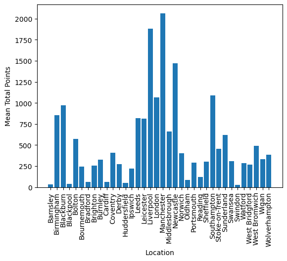

```python
#AN8 Bar Graph: Grouped By Location

plt.bar(grouped_by_loc_mean.index, grouped_by_loc_mean.values)
plt.xlabel("Location")
plt.xticks(rotation=90)
plt.ylabel("Mean Total Points")
plt.show()
```

#### Conclusion

Overall, the analysis conducted here strongly suggests a case for a potential introduction of financial regulatory measures in the league as club spending has a very strong positive correlation with success. While this should not surprising to anyone who follows the league, the narrow distribution of "success" while measured through these lenses would dishearten most fans who wish to see a "fairer" league.

The question of location-based success, while yielding a fairly noticeable trend, would likely need to be studied closer by taking into account unexamined factors that contribute to successes at clubs in more favorable (major cities) locations. For example, while London clubs very evidently tend to do well, attributing a London club's location in the United Kingdom as a direct contributor to its success would be a rather spurious (and rushed) establishment of relationship.